# w209-u09

```python
import matplotlib
import matplotlib.pyplot as plt
import numpy as np
%matplotlib inline
matplotlib.use('PDF')
```

Loads data

```python
import pandas as pd
df = pd.read_csv("C:/Temp/w209/vast-2017-1/Lekagul Sensor Data.csv")
```

```python
list(df)
```

```
['Timestamp', 'car-id', 'car-type', 'gate-name']
```

```python
df.head()
```

|  | Timestamp | car-id | car-type | gate-name |
| --- | --- | --- | --- | --- |
| 0 | 2015-05-01 00:43:28 | 20154301124328-262 | 4 | entrance3 |
| 1 | 2015-05-01 01:03:48 | 20154301124328-262 | 4 | general-gate1 |
| 2 | 2015-05-01 01:06:24 | 20154301124328-262 | 4 | ranger-stop2 |
| 3 | 2015-05-01 01:09:25 | 20154301124328-262 | 4 | ranger-stop0 |
| 4 | 2015-05-01 01:12:36 | 20154301124328-262 | 4 | general-gate2 |

# 1

Plot a histogram of car types at entrance 1.

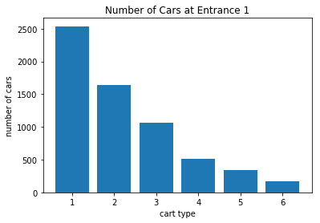

```python
def q1():
    # gets count per car type for entrance 1
    temp = df[df["gate-name"]=="entrance1"][["car-type","car-id"]].groupby("car-type").count()
#     print(temp)

    # builds the x domain for our bar chart
    x = range(1,len(temp.index.tolist())+1)
#     print(x)

    # uses the counts dataframe to get labels we can use for the x domain later
    xlabs = temp.index
#     print(xlabs)

    # builds the y range for our bar chart
    y = temp["car-id"]
#     print(y)

    # builds a bar chart
    plt.bar(x,y)
    plt.title("Number of Cars at Entrance 1")
    plt.xticks(x, xlabs)
    plt.xlabel("cart type")
    plt.ylabel("number of cars")
    plt.show()
q1()
```

# 2

Plot histograms of car types at all entrances.

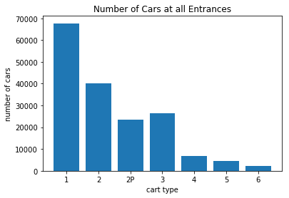

```python
def q2():
    # gets count per car type for all entrances
    temp = df[["car-type","car-id"]].groupby("car-type").count()
#     print(temp)

    # builds the x domain for our bar chart
    x = range(1,len(temp.index.tolist())+1)
#     print(x)

    # uses the counts dataframe to get labels we can use for the x domain later
    xlabs = temp.index
#     print(xlabs)

    # builds the y range for our bar chart
    y = temp["car-id"]
#     print(y)

    # builds a bar chart
    plt.bar(x,y)
    plt.title("Number of Cars at all Entrances")
    plt.xticks(x, xlabs)
    plt.xlabel("cart type")
    plt.ylabel("number of cars")
    plt.show()
q2()
```

# 3

Plot the count of daily visits grouped by day for the whole dataset.

a. Hint: The groupby() method of pandas works like this:

```
g = df.groupby(pd.DatetimeIndex(pd.to_datetime(df["Timestamp"])).date)
```

then you can plot the counts by using g.count()

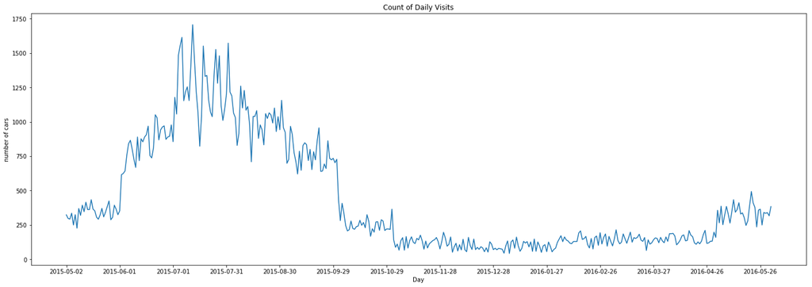

```python
def q3():
    # gets counts per day
    temp = df.groupby(pd.DatetimeIndex(pd.to_datetime(df["Timestamp"])).date).count()
#     print(temp)

    # builds the x domain for our bar chart
    x = range(1,len(temp.index.tolist())+1)
#     print(x)

    # because there are so many days, builds a x ticks list that skips over certain days
    xtx = np.arange(min(x), max(x)+1, 30.0)
#     print(xtx)

    # and because the x ticks are skipped, have to skip over certain x labels too
    xlabs = temp.index[1::30]
#     print(xlabs)

    # builds the y range for our bar chart
    y = temp["car-id"]
#     print(y)

    # builds a line chart
    plt.figure(figsize=(24,8))
    plt.plot(x,y)
    plt.title("Count of Daily Visits")
    plt.xticks(xtx, xlabs)
    plt.xlabel("Day")
    plt.ylabel("number of cars")
    plt.show()
q3()
```

# 4

Same as plot (3), but plot a separate line for each car type.

a. Hint 1: It will help to loop over the car-types, and do a group by within each car-type.

```
for car_type in df["car-type"].unique():
  g = df[df["car-type"] == car_type].groupby(pd.DatetimeIndex(df[df["car-type"] == car_type]["Timestamp"]).date)
```

b. Hint 2: Make sure to add a legend!

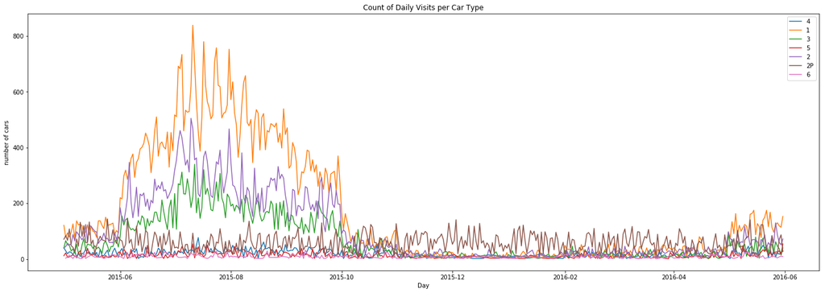

```python
def q4():
    # gets counts per day
    temp = {}
    for car_type in df["car-type"].unique():
        g = df[df["car-type"] == car_type].groupby(pd.DatetimeIndex(df[df["car-type"] == car_type]["Timestamp"]).date).count()["car-type"]
        temp[car_type] = g
#         print(g.head())
#     print(len(temp))
#     print(temp.keys())
#     print(temp.values())

    # builds a line chart
    plt.figure(figsize=(24,8))
    for idx, s in temp.items():
        plt.plot(s, label=idx)
    plt.title("Count of Daily Visits per Car Type")
    plt.xlabel("Day")
    plt.ylabel("number of cars")
    plt.legend()
    plt.show()
q4()
```

# 5

Repeat plot 3, but group by the hour.

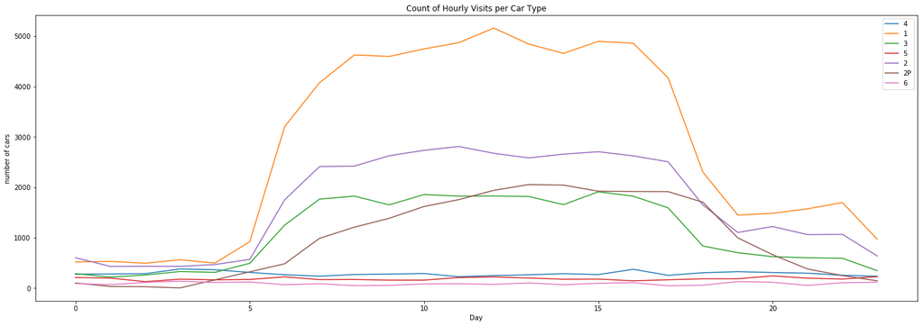

```python
def q5():
    # gets counts per hour
    temp = {}
    for car_type in df["car-type"].unique():
        g = df[df["car-type"] == car_type].groupby(pd.DatetimeIndex(df[df["car-type"] == car_type]["Timestamp"]).hour).count()["car-type"]
        temp[car_type] = g
#         print(g.head())
#     print(len(temp))
#     print(temp.keys())
#     print(temp.values())

    # builds a line chart
    plt.figure(figsize=(24,8))
    for idx, s in temp.items():
        plt.plot(s, label=idx)
    plt.title("Count of Hourly Visits per Car Type")
    plt.xlabel("Day")
    plt.ylabel("number of cars")
    plt.legend()
    plt.show()
q5()
```

# 6

Repeat plot 4, grouping by the day of week, and show a stacked bar chart for each car type.

a. Hint 1: pd.DatetimeIndex has the attribute .dayofweek.

b. Hint 2: You can loop over the car types again, and to stack the bars, use plt.bar() with argument bottom=prev (where prev is the height of the bars from before). It may help to start with prev = np.zeros(7) outside of the loop, and add to it at the end of each loop (prev += g.count().Timestamp.values)

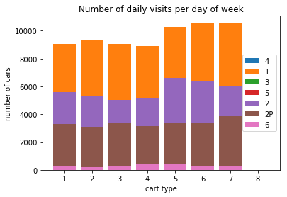

```python
def q6():
    # gets counts of daily visits per day of week
    temp = {}
    for car_type in df["car-type"].unique():
        g = df[df["car-type"] == car_type].groupby(pd.DatetimeIndex(df[df["car-type"] == car_type]["Timestamp"]).dayofweek).count()["car-type"]
        temp[car_type] = g
#     print(temp)

    # for each car type, builds a bar chart
    for idx, s in temp.items():
#         print(s)

        # builds the x domain for our bar chart
        x = range(1,len(s.tolist())+2)
#         print(x)

        # builds the y range for our bar chart
        y = s.values
        y = np.append(y,[0]) # adds a 0 so that we have room for the legend
#         print(y)

        # builds a bar chart
        plt.bar(x, y, label=idx)

    plt.title("Number of daily visits per day of week")
    plt.xlabel("cart type")
    plt.ylabel("number of cars")
    plt.legend(loc="right")
    plt.show()

q6()
```

Did you learn anything interesting about the activity patterns in the park? Upload your six plots and a sentence about what you observe on the Submission tab.